# MUSA 508 Midterm: Zillow Housing Algorithm Assignment

Myron Bañez and Amelia Marcantonio-Fields

10/22/2021

# 1 Introduction:

This project sets out to recreate a home sale price prediction algorithm. The project is loosely based around Zillow’s Zestimate function, and explores potential features that might explain sale prices in Boulder County, CO, USA. Sale prediction algorithms can be important for evaluating what features might affect home price and further might give the ability for people to make more informed decisions about long-term investments. It also may undercover inequities in the housing market that could be addressed. This is an incredibly difficult exercise in both the content (using regressions and Machine Learning to build the models), but also in the data wrangling. While great data is available, it can be hard to quantify features that impact home prices and attribute aspects like “neighborhood-feel” to homes. Further, many variables included may be colinear, meaning that they might relate to one another and then pose challenges on the effectiveness of the model. Our overall modeling strategy was to gather variables that might have an affect on the housing market, clean them, and test them as regressions (to see how meaningful they might be). Once we got a regression model that was moderately meaningful, we continued the process to evaluate it. Our model, unfortunately, has a high percentage of error and is not very generalizable (it does not stand up well to data it does not know). Below is the code and more information on how our model performs.

# 2 Set Up

# 3 Boulder Home Price Data

Below is code to import the working dataset that our model will be based off of. The dataset includes home price sales and characteristics from 2019-2021 in Boulder, CO. The model we will build predicts price and uses some of the internal characteristics from this dataset to inform those predictions.

```r
BoulderHousingData <-
  st_read("studentData.geojson", crs = "ESRI:102254") %>%
  st_transform('ESRI:102653')
## Reading layer `studentData' from data source
##   `C:\Users\ammar\OneDrive\Desktop\CPLN592\Midterm\MUSA_508_Midterm\studentData.geojson'
##   using driver `GeoJSON'
## Simple feature collection with 11364 features and 48 fields
## Geometry type: POINT
## Dimension:     XY
## Bounding box:  xmin: 907857.2 ymin: 535711.1 xmax: 952487.4 ymax: 574366.8
## Projected CRS: NAD_1983_HARN_StatePlane_Colorado_Central_FIPS_0502

Boulder.Boundary <-
  st_read("https://opendata.arcgis.com/datasets/964b8f3b3dbe401bb28d49ac93d29dc4_0.geojson") %>%
  st_transform(st_crs(BoulderHousingData))
## Reading layer `County_Boundary' from data source
##   `https://opendata.arcgis.com/datasets/964b8f3b3dbe401bb28d49ac93d29dc4_0.geojson'
##   using driver `GeoJSON'
## Simple feature collection with 1 feature and 3 fields
## Geometry type: MULTIPOLYGON
## Dimension:     XY
## Bounding box:  xmin: -105.6945 ymin: 39.91297 xmax: -105.0528 ymax: 40.26396
## Geodetic CRS:  WGS 84
```

# 4 Cleaning Internal Variables

For the rest of the code, we will refer to “internal variables” as variables embedded in the Boulder Home Price Data above, or Boulder Housing Data. This chunk of code cleans a few of the variables we will include in our model later on, like total baths.

```r
#Adding a price/sq foot variable and total baths variable

BoulderHousingData <-
  BoulderHousingData %>%
  mutate(pricesqft = ifelse(TotalFinishedSF > 0, (price/TotalFinishedSF), 0),
        totalbaths = (nbrHalfBaths *0.5)+(nbrThreeQtrBaths)+(nbrFullBaths*1))
```

# 5 Adding Data: Amenities/Public Services

In order to start building a model off of potential features that relate to the housing market, we must import some external variables! The code below pulls in data that is categorized as either an amenity or public service. The data below is sourced from: https://www.bouldercounty.org/government/open-data/ and https://www.cde.state.co.us/schoolview

```r
BoulderLibraries <-
   st_read("https://opendata.arcgis.com/datasets/7f4ea25ba87345e380d2e896611d2588_0.geojson") %>%
  st_transform(st_crs(BoulderHousingData))
## Reading layer `Libraries' from data source
##   `https://opendata.arcgis.com/datasets/7f4ea25ba87345e380d2e896611d2588_0.geojson'
##   using driver `GeoJSON'
## Simple feature collection with 19 features and 7 fields
## Geometry type: POINT
## Dimension:     XY
## Bounding box:  xmin: -105.5099 ymin: 39.96059 xmax: -105.0989 ymax: 40.22287
## Geodetic CRS:  WGS 84

BoulderTrailHeads <-
   st_read("https://opendata.arcgis.com/datasets/3a950053bbef46c6a3c2abe3aceee3de_0.geojson") %>%
  st_transform(st_crs(BoulderHousingData))
## Reading layer `Boulder_Area_Trailheads' from data source
##   `https://opendata.arcgis.com/datasets/3a950053bbef46c6a3c2abe3aceee3de_0.geojson'
##   using driver `GeoJSON'
## Simple feature collection with 331 features and 9 fields
## Geometry type: POINT
## Dimension:     XY
## Bounding box:  xmin: -105.8584 ymin: 39.91423 xmax: -105.009 ymax: 40.44153
## Geodetic CRS:  WGS 84

BoulderOpenSpace <-
   st_read("https://opendata.arcgis.com/datasets/61728921abcb481fa98b9b07cfd7c95d_0.geojson") %>%
  st_transform(st_crs(BoulderHousingData))
## Reading layer `County_Open_Space' from data source
##   `https://opendata.arcgis.com/datasets/61728921abcb481fa98b9b07cfd7c95d_0.geojson'
##   using driver `GeoJSON'
## Simple feature collection with 2063 features and 24 fields
## Geometry type: MULTIPOLYGON
## Dimension:     XY
## Bounding box:  xmin: -105.6661 ymin: 39.89269 xmax: -105.017 ymax: 40.26848
## Geodetic CRS:  WGS 84

BoulderMarijuanaEstablishments <-
   st_read("https://opendata.arcgis.com/datasets/425a0adb547a4faba4b741a4fe4373b1_0.geojson") %>%
  st_transform(st_crs(BoulderHousingData))
## Reading layer `Marijuana_Establishments' from data source
##   `https://opendata.arcgis.com/datasets/425a0adb547a4faba4b741a4fe4373b1_0.geojson'
##   using driver `GeoJSON'
## Simple feature collection with 33 features and 28 fields
## Geometry type: POINT
## Dimension:     XY
## Bounding box:  xmin: -105.286 ymin: 40.00162 xmax: -105.1021 ymax: 40.21266
## Geodetic CRS:  WGS 84

BoulderLakesandReservoirs <-
   st_read("https://opendata.arcgis.com/datasets/e0759cd6dc8f4990a04b77a29c988b55_0.geojson") %>%
   st_transform(st_crs(BoulderHousingData))
## Reading layer `Lakes_and_Reservoirs' from data source
##   `https://opendata.arcgis.com/datasets/e0759cd6dc8f4990a04b77a29c988b55_0.geojson'
##   using driver `GeoJSON'
## Simple feature collection with 2043 features and 27 fields
## Geometry type: MULTIPOLYGON
## Dimension:     XY
## Bounding box:  xmin: -105.6983 ymin: 39.852 xmax: -104.9438 ymax: 40.34869
## Geodetic CRS:  WGS 84

BoulderSchools <-
  st_read("BoulderSchools_Geocode_Proj.shp", crs = "ESRI:102653")
## Reading layer `BoulderSchools_Geocode_Proj' from data source
##   `C:\Users\ammar\OneDrive\Desktop\CPLN592\Midterm\MUSA_508_Midterm\BoulderSchools_Geocode_Proj.shp'
##   using driver `ESRI Shapefile'
## Simple feature collection with 207 features and 84 fields
## Geometry type: POINT
## Dimension:     XY
## Bounding box:  xmin: 2992787 ymin: 1212206 xmax: 7752053 ymax: 2501119
## Projected CRS: NAD_1983_StatePlane_Colorado_North_FIPS_0501_Feet

BoulderPublicSchools <- subset(BoulderSchools, BoulderSchools$USER_Publi == 1)
BoulderPrivateSchools <- subset(BoulderSchools, BoulderSchools$USER_Publi == 0)
```

# 6 Adding Data: Spatial Structure

We also included variables that relate to the demographic and environmental makeup of Boulder, CO. Variables below are from: https://www.socialexplorer.com/home and https://www.bouldercounty.org/government/open-data/

```r
#race, median household income, education levels
BoulderCensusData <-
  st_read("BoulderCO_Proj.shp", crs = "ESRI:102653")
## Reading layer `BoulderCO_Proj' from data source
##   `C:\Users\ammar\OneDrive\Desktop\CPLN592\Midterm\MUSA_508_Midterm\BoulderCO_Proj.shp'
##   using driver `ESRI Shapefile'
## Simple feature collection with 200 features and 25 fields
## Geometry type: MULTIPOLYGON
## Dimension:     XY
## Bounding box:  xmin: 2945512 ymin: 1211128 xmax: 3125345 ymax: 1338641
## Projected CRS: NAD_1983_StatePlane_Colorado_North_FIPS_0501_Feet

BoulderCensusData <-
  BoulderCensusData %>%
  mutate(BG = GEOID)

BoulderScenicCorridor <-
   st_read("https://opendata.arcgis.com/datasets/749ed0a11e454f64a0e5f7c51a786129_0.geojson") %>%
   st_transform(st_crs(BoulderHousingData))
## Reading layer `Peak_To_Peak_Scenic_Corridor' from data source
##   `https://opendata.arcgis.com/datasets/749ed0a11e454f64a0e5f7c51a786129_0.geojson'
##   using driver `GeoJSON'
## Simple feature collection with 1593 features and 6 fields
## Geometry type: MULTIPOLYGON
## Dimension:     XY
## Bounding box:  xmin: -105.5472 ymin: 39.93224 xmax: -105.4367 ymax: 40.26143
## Geodetic CRS:  WGS 84

BoulderGeologicalHazards <-
   st_read("https://opendata.arcgis.com/datasets/ccb02305e30346a4848c99ff94a0e928_0.geojson") %>%
   st_transform(st_crs(BoulderHousingData))
## Reading layer `Geological_Hazards' from data source
##   `https://opendata.arcgis.com/datasets/ccb02305e30346a4848c99ff94a0e928_0.geojson'
##   using driver `GeoJSON'
## Simple feature collection with 303 features and 9 fields
## Geometry type: POLYGON
## Dimension:     XY
## Bounding box:  xmin: -105.6945 ymin: 39.91318 xmax: -105.0528 ymax: 40.26396
## Geodetic CRS:  WGS 84

BoulderFloodZones <-
   st_read("https://opendata.arcgis.com/datasets/a9624bd25d854ef7ab0d543e9490ce48_0.geojson") %>%
   st_transform(st_crs(BoulderHousingData))
## Reading layer `Flood_2013_Inundated_Areas' from data source
##   `https://opendata.arcgis.com/datasets/a9624bd25d854ef7ab0d543e9490ce48_0.geojson'
##   using driver `GeoJSON'
## Simple feature collection with 165 features and 6 fields
## Geometry type: MULTIPOLYGON
## Dimension:     XY
## Bounding box:  xmin: -105.4942 ymin: 39.91283 xmax: -105.0547 ymax: 40.26225
## Geodetic CRS:  WGS 84

BoulderWildfireHistory <-
   st_read("https://opendata.arcgis.com/datasets/61f20f4a64274969a9e740eda5c62de7_0.geojson") %>%
   st_transform(st_crs(BoulderHousingData))
## Reading layer `Wildfire_History' from data source
##   `https://opendata.arcgis.com/datasets/61f20f4a64274969a9e740eda5c62de7_0.geojson'
##   using driver `GeoJSON'
## Simple feature collection with 42 features and 7 fields
## Geometry type: MULTIPOLYGON
## Dimension:     XY
## Bounding box:  xmin: -105.5855 ymin: 39.91812 xmax: -105.2345 ymax: 40.23306
## Geodetic CRS:  WGS 84
```

# 7 Adding External Variables to the Big Dataset

To start conducting analysis, we must reconfigure certain variables and attribute them to specific home sales. The code below goes through this process. We used three different types of methodology to measure both distance and occurrences, which were fixed-buffer analysis (set counts in a half mile radius), k-nearest neighborhood (distance to a number of institutions), and spatial join of both descriptive and binary attributes. In sum, we introduced variables that related to open space, lakes and reservoirs, libraries, trailheads, schools, marijuana establishments, scenery, flood zones, wildfires, census data, and geological hazards to see if they would be meaningful to the predictions.

```r
# Fixed Buffer Distance: Open Space & Lakes + Reservoirs

#Singling out geometry:
BoulderOpenSpaceGeo <- BoulderOpenSpace %>%
  select(geometry)
BoulderLakesandReservoirsGeo <- BoulderLakesandReservoirs %>%
  select(geometry)

BoulderHousingData.Buffer.OpenSpace =
  BoulderHousingData %>%
    st_buffer(2640) %>%
    stats::aggregate(mutate(BoulderLakesandReservoirsGeo, counter = 1),., sum) %>%
    pull(counter)

BoulderHousingData.Buffer.OpenSpace =
  ifelse(is.na(BoulderHousingData.Buffer.OpenSpace),0, 1)

BoulderHousingData.Buffer.LR =
   BoulderHousingData %>%
    st_buffer(2640) %>%
    stats::aggregate(mutate(BoulderLakesandReservoirsGeo, counter = 1),., sum) %>%
    pull(counter)

BoulderHousingData.Buffer.LR =
  ifelse(is.na(BoulderHousingData.Buffer.LR),0, 1)

BoulderHousingData <-
  cbind(BoulderHousingData, BoulderHousingData.Buffer.OpenSpace)

BoulderHousingData <-
  cbind(BoulderHousingData, BoulderHousingData.Buffer.LR)

# K-Nearest Neighbor: Libraries, Trail Heads, Marijuana Establishments, Schools (public and private)

st_c <- st_coordinates

BoulderHousingData <-
  BoulderHousingData %>%
    mutate(
      libraries_nn1 = nn_function(st_c(BoulderHousingData), st_c(BoulderLibraries), 1),
      libraries_nn2 = nn_function(st_c(BoulderHousingData), st_c(BoulderLibraries), 2),
      libraries_nn3 = nn_function(st_c(BoulderHousingData), st_c(BoulderLibraries), 3),
      libraries_nn4 = nn_function(st_c(BoulderHousingData), st_c(BoulderLibraries), 4),
      libraries_nn5 = nn_function(st_c(BoulderHousingData), st_c(BoulderLibraries), 5))

BoulderHousingData <-
  BoulderHousingData %>%
    mutate(
      trailheads_nn1 = nn_function(st_c(BoulderHousingData), st_c(BoulderTrailHeads), 1),
      trailheads_nn2 = nn_function(st_c(BoulderHousingData), st_c(BoulderTrailHeads), 2),
      trailheads_nn3 = nn_function(st_c(BoulderHousingData), st_c(BoulderTrailHeads), 3),
      trailheads_nn4 = nn_function(st_c(BoulderHousingData), st_c(BoulderTrailHeads), 4),
      trailheads_nn5 = nn_function(st_c(BoulderHousingData), st_c(BoulderTrailHeads), 5))

BoulderHousingData <-
  BoulderHousingData %>%
    mutate(
      ME_nn1 = nn_function(st_c(BoulderHousingData), st_c(BoulderMarijuanaEstablishments), 1),
      ME_nn2 = nn_function(st_c(BoulderHousingData), st_c(BoulderMarijuanaEstablishments), 2),
      ME_nn3 = nn_function(st_c(BoulderHousingData), st_c(BoulderMarijuanaEstablishments), 3),
      ME_nn4 = nn_function(st_c(BoulderHousingData), st_c(BoulderMarijuanaEstablishments), 4),
      ME_nn5 = nn_function(st_c(BoulderHousingData), st_c(BoulderMarijuanaEstablishments), 5))

BoulderHousingData <-
  BoulderHousingData %>%
    mutate(
      public_nn1 = nn_function(st_c(BoulderHousingData), st_c(BoulderPublicSchools), 1),
      public_nn2 = nn_function(st_c(BoulderHousingData), st_c(BoulderPublicSchools), 2),
      public_nn3 = nn_function(st_c(BoulderHousingData), st_c(BoulderPublicSchools), 3),
      public_nn4 = nn_function(st_c(BoulderHousingData), st_c(BoulderPublicSchools), 4),
      public_nn5 = nn_function(st_c(BoulderHousingData), st_c(BoulderPublicSchools), 5))

BoulderHousingData <-
  BoulderHousingData %>%
    mutate(
      private_nn1 = nn_function(st_c(BoulderHousingData), st_c(BoulderPrivateSchools), 1),
      private_nn2 = nn_function(st_c(BoulderHousingData), st_c(BoulderPrivateSchools), 2),
      private_nn3 = nn_function(st_c(BoulderHousingData), st_c(BoulderPrivateSchools), 3),
      private_nn4 = nn_function(st_c(BoulderHousingData), st_c(BoulderPrivateSchools), 4),
      private_nn5 = nn_function(st_c(BoulderHousingData), st_c(BoulderPrivateSchools), 5))

# St_Join: Census, Scenic, Geological Hazards, Floodzones, Wildfire
BoulderHousingData <-
  st_join(BoulderHousingData, BoulderCensusData)

BoulderHousingData <-
  st_join(BoulderHousingData, BoulderGeologicalHazards)


BoulderScenicCorridor <-
 BoulderScenicCorridor %>%
 mutate(SC = 1)

BoulderFloodZones <-
 BoulderFloodZones %>%
 mutate(FZ = 1)


BoulderWildfireHistory <-
 BoulderWildfireHistory %>%
 mutate(WF = 1)

BoulderHousingData <-
  st_join(BoulderHousingData, BoulderScenicCorridor)

BoulderHousingData$SC =
  ifelse(is.na(BoulderHousingData$SC),0, 1)

BoulderHousingData <-
  st_join(BoulderHousingData, BoulderFloodZones)

BoulderHousingData$FZ =
  ifelse(is.na(BoulderHousingData$FZ),0, 1)

BoulderHousingData <-
  st_join(BoulderHousingData, BoulderWildfireHistory)

BoulderHousingData$WF =
  ifelse(is.na(BoulderHousingData$WF),0, 1)
```

# 8 Price Sold Map

This is a map of the homes sold from 2019-2021 by price sold to give further context to the area.

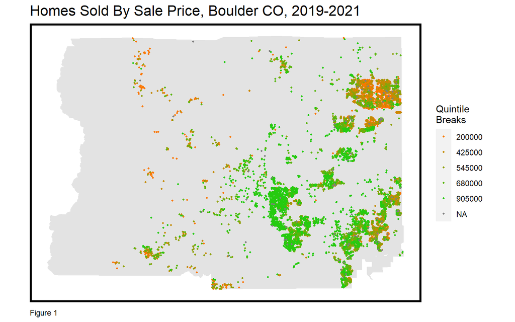

```r
options(scipen = 9999)

#Home Price

ggplot() +
  geom_sf(data = Boulder.Boundary, fill = "grey89", color = "grey89") +
  geom_sf(data = BoulderHousingData, aes(colour = q5(price)),
          show.legend = "point", size = .75) +
  scale_colour_manual(values = palette5,
                   labels=qBr(BoulderHousingData,"price"),
                   name="Quintile\nBreaks") +
  labs(title="Homes Sold By Sale Price, Boulder CO, 2019-2021",
      caption="Figure 1") +
  mapTheme()
```

# 9 Internal Variables Map

The following are maps of internal housing characteristics that were included in the modeling process.

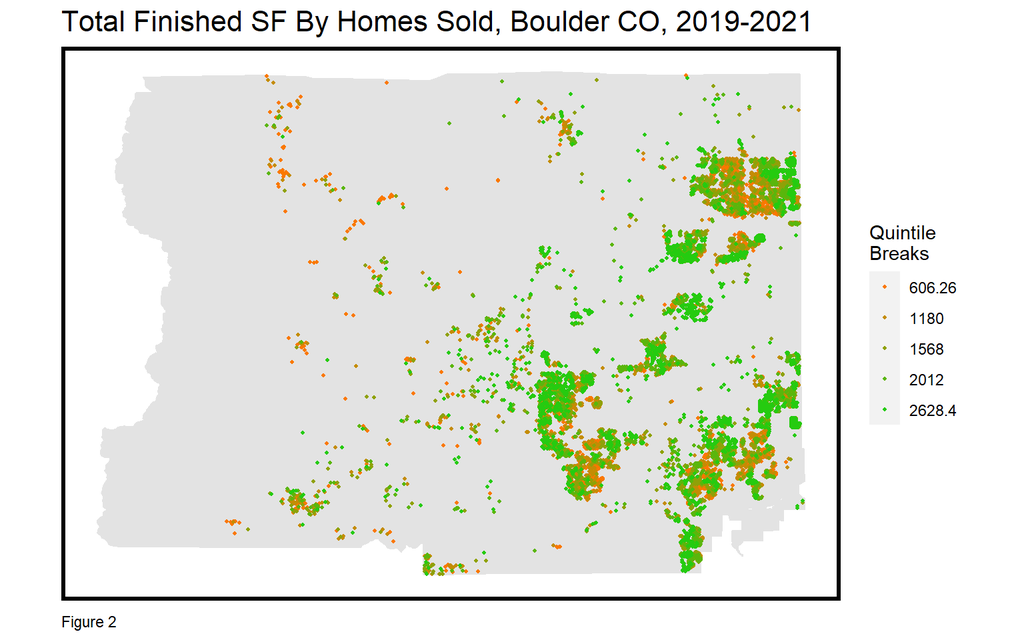

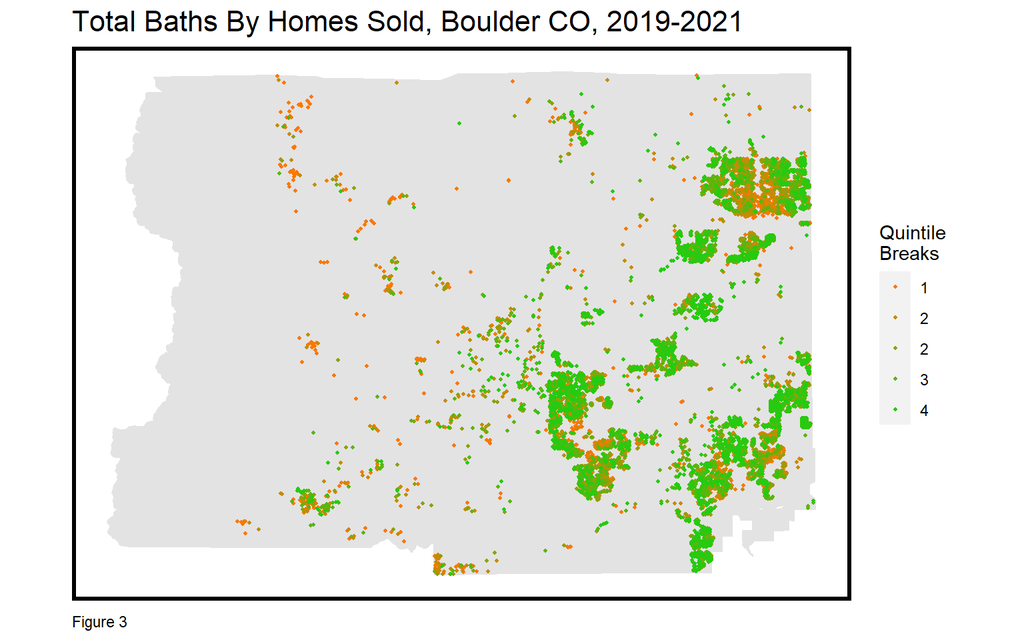

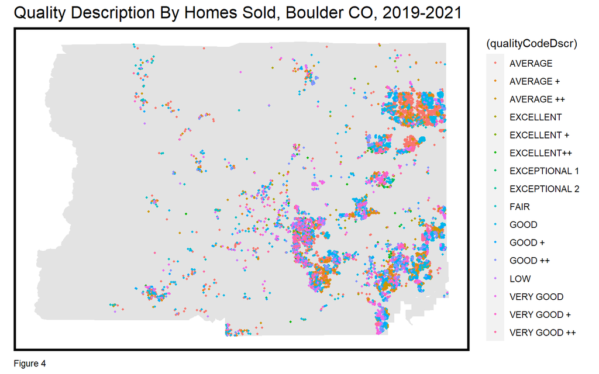

```r
options(scipen = 9999)

#Internal Variables
ggplot() +
  geom_sf(data = Boulder.Boundary, fill = "grey89", color = "grey89") +
  geom_sf(data = BoulderHousingData, aes(colour = q5(TotalFinishedSF)),
          show.legend = "point", size = .75) +
  scale_colour_manual(values = palette5,
                   labels=qBr(BoulderHousingData,"TotalFinishedSF"),
                   name="Quintile\nBreaks") +
  labs(title="Total Finished SF By Homes Sold, Boulder CO, 2019-2021",
       caption="Figure 2") +
  mapTheme()

ggplot() +
  geom_sf(data = Boulder.Boundary, fill = "grey89", color = "grey89") +
  geom_sf(data = BoulderHousingData, aes(colour = q5(totalbaths)),
          show.legend = "point", size = .75) +
  scale_colour_manual(values = palette5,
                   labels=qBr(BoulderHousingData,"totalbaths"),
                   name="Quintile\nBreaks") +
  labs(title="Total Baths By Homes Sold, Boulder CO, 2019-2021",
      caption="Figure 3") +
  mapTheme()

ggplot() +
  geom_sf(data = Boulder.Boundary, fill = "grey89", color = "grey89") +
  geom_sf(data = BoulderHousingData, aes(colour = (qualityCodeDscr)),
          show.legend = "point", size = .75) +
  labs(title="Quality Description By Homes Sold, Boulder CO, 2019-2021",
       caption="Figure 4") +
  mapTheme()
```

# 10 Amenities/Services Maps

Below are a series of maps that begin to speak to the relationship between sold home prices and amenities/services across the county. Marijuana Establishments was included in the analysis as that is a variable that is pretty unique to Colorado. Some of these maps may show descriptive relationships, like how there are a lot of trail heads by expensive homes, but we will explore more of this significance later on.

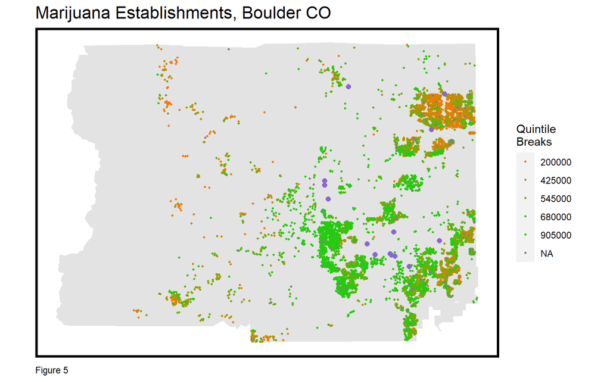

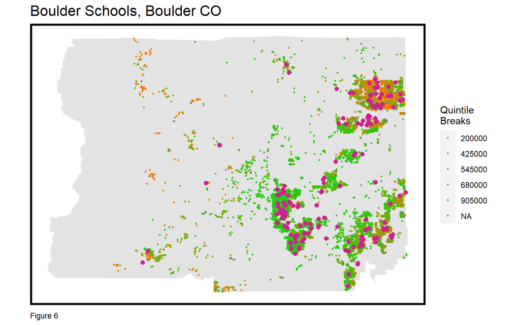

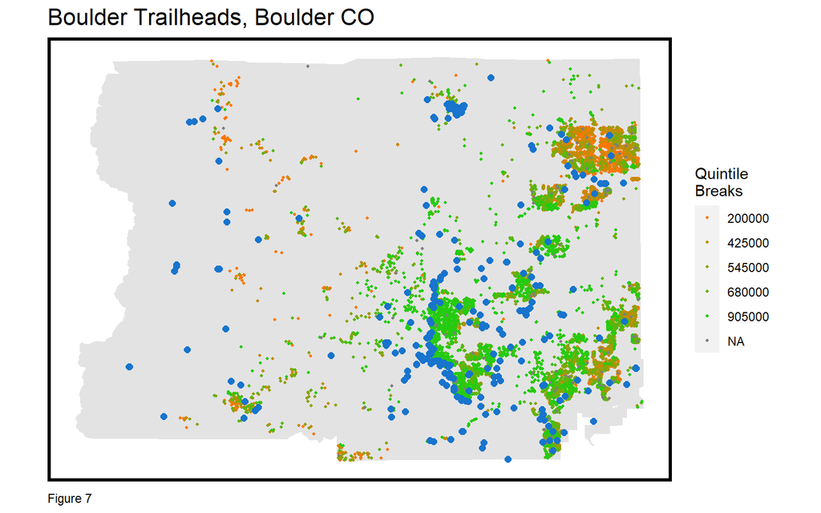

```r
BoulderSchools1 <- st_intersection(Boulder.Boundary, BoulderSchools)

BoulderTrailHeads1 <- st_intersection(Boulder.Boundary, BoulderTrailHeads)

ggplot() +
  geom_sf(data = Boulder.Boundary, fill = "grey89", color = "grey89") +
  geom_sf(data = BoulderHousingData, aes(colour = q5(price)),
          show.legend = "point", size = .75) +
  scale_colour_manual(values = palette5,
                   labels=qBr(BoulderHousingData,"price"),
                   name="Quintile\nBreaks") +
  geom_sf(data = BoulderMarijuanaEstablishments, color = "mediumpurple3", size = 2) +
  labs(title="Marijuana Establishments, Boulder CO",
       caption="Figure 5") +
  mapTheme()

ggplot() +
  geom_sf(data = Boulder.Boundary, fill = "grey89", color = "grey89") +
  geom_sf(data = BoulderHousingData, aes(colour = q5(price)),
          show.legend = "point", size = .75) +
  scale_colour_manual(values = palette5,
                   labels=qBr(BoulderHousingData,"price"),
                   name="Quintile\nBreaks") +
  geom_sf(data = BoulderSchools1, color = "violetred", size = 2) +
  labs(title="Boulder Schools, Boulder CO",
      caption="Figure 6") +
  mapTheme()

ggplot() +
  geom_sf(data = Boulder.Boundary, fill = "grey89", color = "grey89") +
  geom_sf(data = BoulderHousingData, aes(colour = q5(price)),
          show.legend = "point", size = .75) +
  scale_colour_manual(values = palette5,
                   labels=qBr(BoulderHousingData,"price"),
                   name="Quintile\nBreaks") +
  geom_sf(data = BoulderTrailHeads1, color = "dodgerblue3", size = 2) +
  labs(title="Boulder Trailheads, Boulder CO",
       caption="Figure 7") +
  mapTheme()
```

# 11 Spatial Variables Maps

Lastly, there are maps on spatial variables and home prices. Geological Hazards is another variable that we will explore in more depth later on.

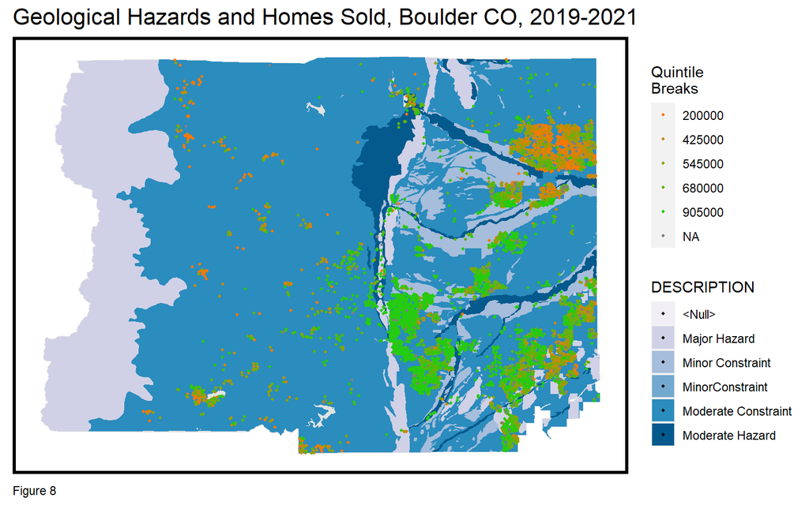

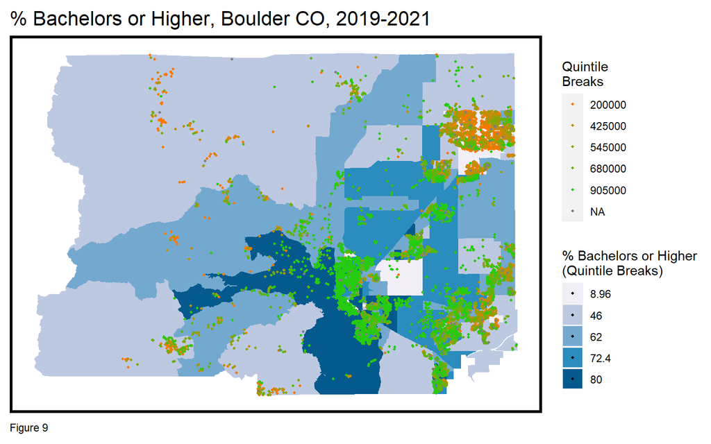

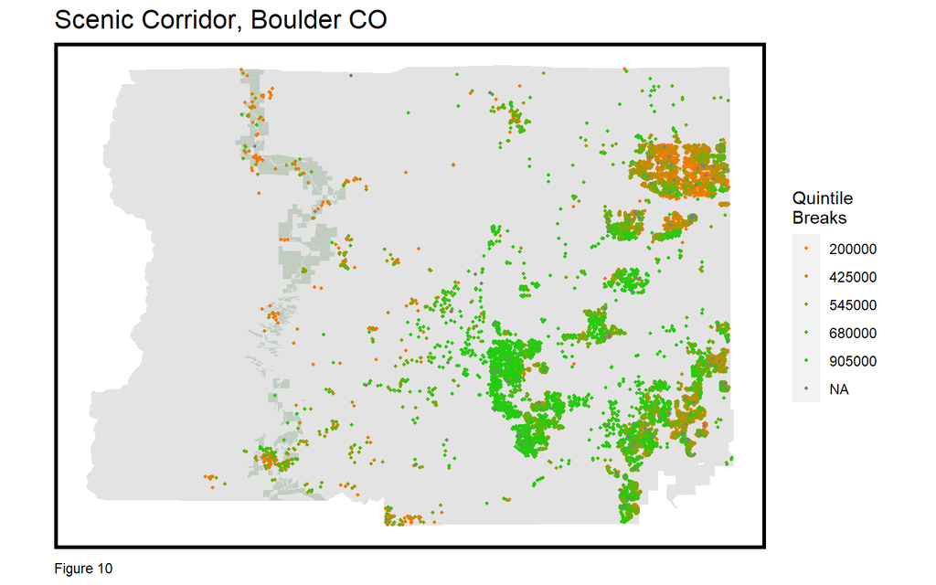

```r
#want to change color

ggplot() +
  geom_sf(data = Boulder.Boundary, fill = "grey89", color = "grey89") +
  geom_sf(data = BoulderGeologicalHazards, aes(fill = DESCRIPTION), color = "transparent") +
  scale_fill_brewer(palette = "PuBu") +
  geom_sf(data = BoulderHousingData, aes(colour = q5(price)),
          show.legend = "point", size = .75) +
  scale_colour_manual(values = palette5,
                   labels=qBr(BoulderHousingData,"price"),
                   name="Quintile\nBreaks") +
  labs(title="Geological Hazards and Homes Sold, Boulder CO, 2019-2021",
       caption="Figure 8") +
  mapTheme()


ggplot() +
  geom_sf(data = BoulderCensusData, aes(fill = q5(PerBDorHig)), color = "transparent") +
    scale_fill_brewer(palette = "PuBu",
                      labels = qBr(BoulderCensusData, "PerBDorHig"),
                      name = "% Bachelors or Higher\n(Quintile Breaks)") +
  geom_sf(data = BoulderHousingData, aes(colour = q5(price)),
          show.legend = "point", size = .75) +
  scale_colour_manual(values = palette5,
                   labels=qBr(BoulderHousingData,"price"),
                   name="Quintile\nBreaks") +
  labs(title="% Bachelors or Higher, Boulder CO, 2019-2021",
      caption="Figure 9") +
  mapTheme()


ggplot() +
  geom_sf(data = Boulder.Boundary, fill = "grey89", color = "grey89") +
  geom_sf(data = BoulderScenicCorridor, fill = "honeydew3",  color = "transparent") +
  geom_sf(data = BoulderHousingData, fill = "grey50", color = "grey50",
          show.legend = "point", size = .75) +
  geom_sf(data = BoulderHousingData, aes(colour = q5(price)),
          show.legend = "point", size = .75) +
  scale_colour_manual(values = palette5,
                   labels=qBr(BoulderHousingData,"price"),
                   name="Quintile\nBreaks") +
  labs(title="Scenic Corridor, Boulder CO",
       caption="Figure 10") +
  mapTheme()
```

```r
## Setting toPrecict==0
Training_Boulder <- filter(BoulderHousingData, toPredict == 0) #removed 100
```

# 12 Exploratory Data Analysis: Correlations

The next chunk of code begins to explore the relationships between the variables and home prices. Below are scatterplots, descriptive statistics, and a barplot. For example, the last chart is a barplot of quality by house price, indicating that the higher the quality of the house, the more expensive the house sells for. These help inform which variables we pick for the model later on.

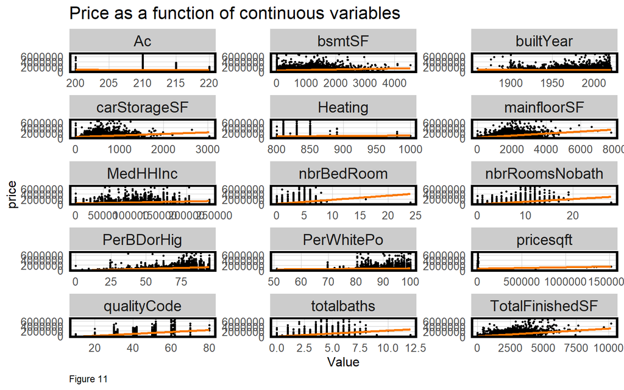

```r
options(scipen = 9999) #turns off scientific notation and how many points

Training_BoulderPlot <- ## IMPORTANT
  Training_Boulder %>%
  filter(price < 10000000)

## Scatterplot
st_drop_geometry(Training_BoulderPlot) %>%
  dplyr::select(price, pricesqft, totalbaths, qualityCode, builtYear, bsmtSF, carStorageSF,nbrBedRoom,
                nbrRoomsNobath, mainfloorSF, TotalFinishedSF, Ac, Heating, PerBDorHig, PerWhitePo,
                MedHHInc, ) %>%
  filter(price < 10000000) %>%
  gather(Variable, Value, -price) %>%
   ggplot(aes(Value, price)) +
     geom_point(size = .5) + geom_smooth(method = "lm", se=F, colour = "#FA7800") +
     facet_wrap(~Variable, ncol = 3, scales = "free") +
     labs(title = "Price as a function of continuous variables",
          caption="Figure 11") +
     plotTheme()
## `geom_smooth()` using formula 'y ~ x'
```

```r
## Polished training set table
#--- Internal
ss_boulderInternal <- Training_Boulder %>%
  dplyr::select("pricesqft", "totalbaths", "qualityCode", "builtYear", "bsmtSF", "carStorageSF", "nbrBedRoom", "nbrRoomsNobath", "mainfloorSF", "TotalFinishedSF", "Ac", "Heating", "PerBDorHig","PerWhitePo","MedHHInc")

ss_boulder <- st_drop_geometry(ss_boulderInternal)

stargazer(as.data.frame(ss_boulderInternal), type="text", digits=1, title="Table 1: Descriptive Statistics for Boulder Homes Internal Variables", out = "Training_BoulderInternal.txt", caption="Figure 12")
```

```
##
## Table 1: Descriptive Statistics for Boulder Homes Internal Variables
## ===========================================================================
## Statistic         N      Mean    St. Dev.  Min  Pctl(25) Pctl(75)    Max
## ---------------------------------------------------------------------------
## pricesqft       11,264  1,085.4  29,927.0   0    261.3    473.6   1,520,000
## totalbaths      11,264    2.7      1.0      0      2       3.5       12
## qualityCode     11,264   37.3      7.9     10      30       41       80
## builtYear       11,264  1,987.2    26.8   1,860  1,972    2,006     2,021
## bsmtSF          11,264   744.1    627.7     0    135.5    1,126     4,534
## carStorageSF    11,264   471.6    235.8     0     380      600      3,040
## nbrBedRoom      11,264    3.4      1.1      0      3        4        24
## nbrRoomsNobath  11,264    7.4      2.1      0      6        9        28
## mainfloorSF     11,264  1,313.1   607.5     0    922.8    1,619     7,795
## TotalFinishedSF 11,264  1,954.5   891.6     0    1,276    2,443    10,188
## Ac              7,423    210.1     1.3    200.0  210.0    210.0     220.0
## Heating         11,160   814.0     14.8   800.0  810.0    810.0    1,000.0
## PerBDorHig      11,264   63.4      16.4    0.0    53.3     73.9     94.8
## PerWhitePo      11,264   89.9      5.4     51     87.0     93.4      100
## MedHHInc        11,264 102,743.5 34,996.1   0    81,518  123,750   241,161
## ---------------------------------------------------------------------------
##
## Table 1: Descriptive Statistics for Boulder Homes Internal Variables
## =========
## Figure 12
## ---------
```

```r
#--- External
ss_boulderExternal <- Training_Boulder %>%
  dplyr::select("Ac", "Heating", "PerBDorHig","PerWhitePo","MedHHInc")

ss_boulder <- st_drop_geometry(ss_boulderExternal)

stargazer(as.data.frame(ss_boulderExternal), type="text", digits=1, title="Table 1: Descriptive Statistics for Boulder Homes External Variables", out = "Training_BoulderExternal.txt", caption="Figure 13")
```

```
##
## Table 1: Descriptive Statistics for Boulder Homes External Variables
## ====================================================================
## Statistic    N      Mean    St. Dev.  Min  Pctl(25) Pctl(75)   Max
## --------------------------------------------------------------------
## Ac         7,423    210.1     1.3    200.0  210.0    210.0    220.0
## Heating    11,160   814.0     14.8   800.0  810.0    810.0   1,000.0
## PerBDorHig 11,264   63.4      16.4    0.0    53.3     73.9    94.8
## PerWhitePo 11,264   89.9      5.4     51     87.0     93.4     100
## MedHHInc   11,264 102,743.5 34,996.1   0    81,518  123,750  241,161
## --------------------------------------------------------------------
##
## Table 1: Descriptive Statistics for Boulder Homes External Variables
## =========
## Figure 13
## ---------
```

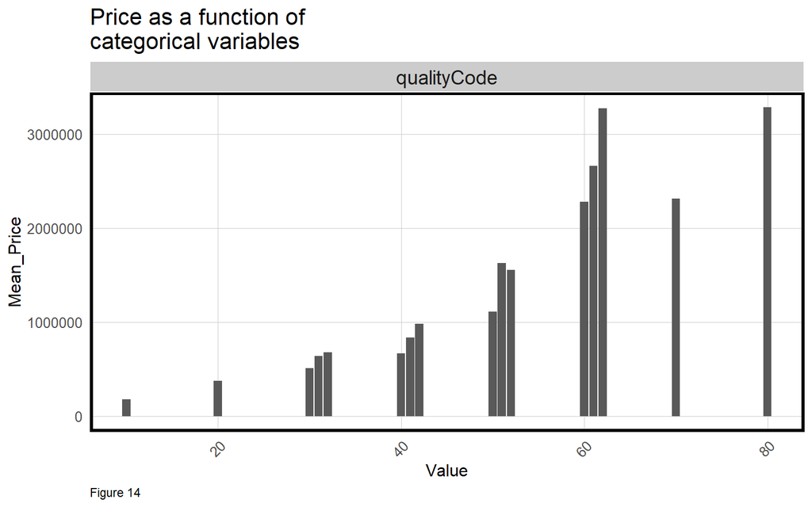

```r
## Barplot
plot <-
  st_drop_geometry(Training_Boulder) %>%
  dplyr::select(price, qualityCode) %>%
  gather(Variable, Value, -price) %>%
   ggplot(aes(Value, price)) +
     geom_bar(position = "dodge", stat = "summary", fun.y = "mean") +
     facet_wrap(~Variable, ncol = 1, scales = "free") +
     labs(title = "Price as a function of\ncategorical variables", y = "Mean_Price",
          caption="Figure 14") +
     plotTheme() + theme(axis.text.x = element_text(angle = 45, hjust = 1))

plot
## No summary function supplied, defaulting to `mean_se()`
```

# 13 Exploratory Data Analysis: Correlation Matrix

Below is another visualization explaining correlation. For this visualization, we are mostly focused on price and how it relates to the variables that might be included in the model. We notice that there are some variables with strong positive and negative correlations, which begins our selection process.

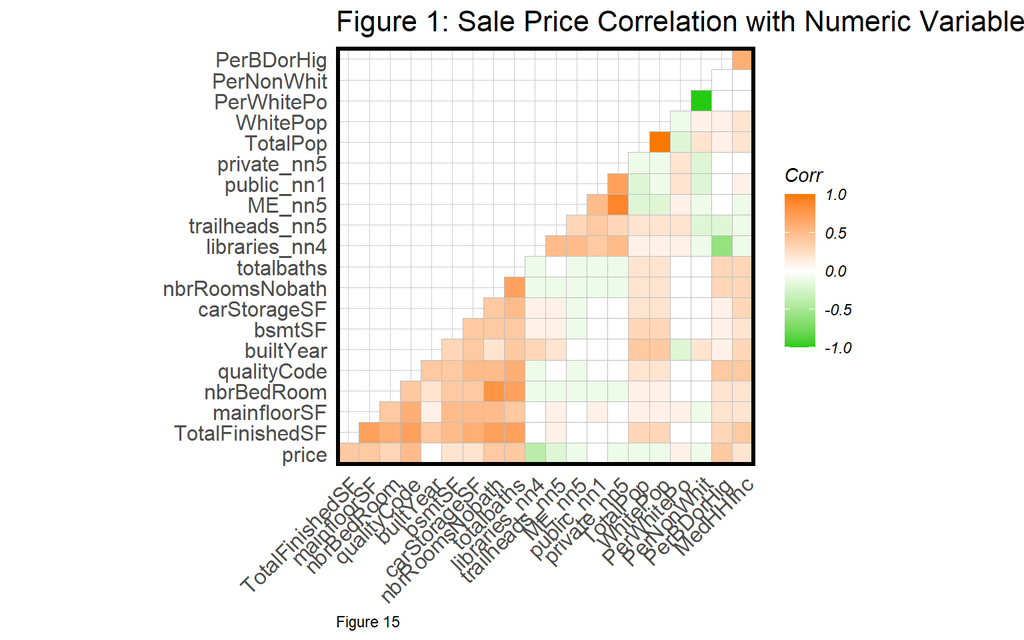

```r
## Correlation Matrix

numericVars <- st_drop_geometry(Training_Boulder) %>%
  dplyr::select(price, TotalFinishedSF, mainfloorSF, nbrBedRoom, qualityCode, builtYear, bsmtSF, carStorageSF, nbrRoomsNobath, totalbaths, libraries_nn4, trailheads_nn5, ME_nn5, public_nn1, private_nn5, TotalPop, WhitePop, PerWhitePo, PerNonWhit, PerBDorHig, MedHHInc) %>%
  select(where(is.numeric)) %>%
  na.omit()

ggcorrplot(
  round(cor(numericVars), 1),
  p.mat = cor_pmat(numericVars),
  colors = c("#25CB10", "white", "#FA7800"),
  type="lower",
  insig = "blank") +
    labs(title = "Figure 1: Sale Price Correlation with Numeric Variables",
         caption="Figure 15") +
  plotTheme()
```

```r
## Pearson's Test
cor.test(Training_Boulder$price, Training_Boulder$libraries_nn1, method = "pearson")
```

```
##
##  Pearson's product-moment correlation
##
## data:  Training_Boulder$price and Training_Boulder$libraries_nn1
## t = -2.7543, df = 11262, p-value = 0.005892
## alternative hypothesis: true correlation is not equal to 0
## 95 percent confidence interval:
##  -0.044391355 -0.007481029
## sample estimates:
##         cor
## -0.02594503
```

# 14 4 Interesting Scatterplots

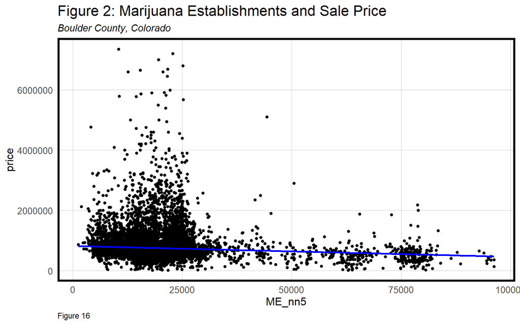

```r
## Marijuana Establishments
ggplot(data = Training_BoulderPlot, aes(x = ME_nn5, y = price)) +
  geom_point(size=2, shape=20)  +
  labs(title = "Figure 2: Marijuana Establishments and Sale Price", subtitle = "Boulder County, Colorado", caption="Figure 16") +
  geom_smooth(method = "lm", se=F, colour = "blue") +
  plotTheme()
## `geom_smooth()` using formula 'y ~ x'
```

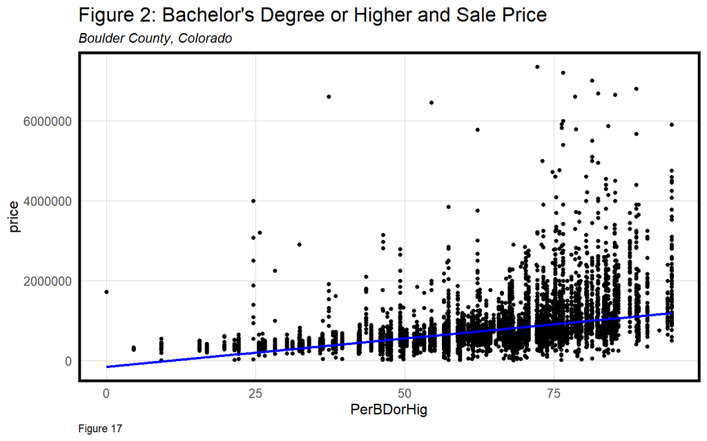

```r
## Bachelor's Degree or Higher
ggplot(data = Training_BoulderPlot, aes(x = PerBDorHig, y = price)) +
  geom_point(size=2, shape=20)  +
  labs(title = "Figure 2: Bachelor's Degree or Higher and Sale Price", subtitle = "Boulder County, Colorado", caption="Figure 17") +
  geom_smooth(method = "lm", se=F, colour = "blue") +
  plotTheme()
## `geom_smooth()` using formula 'y ~ x'
```

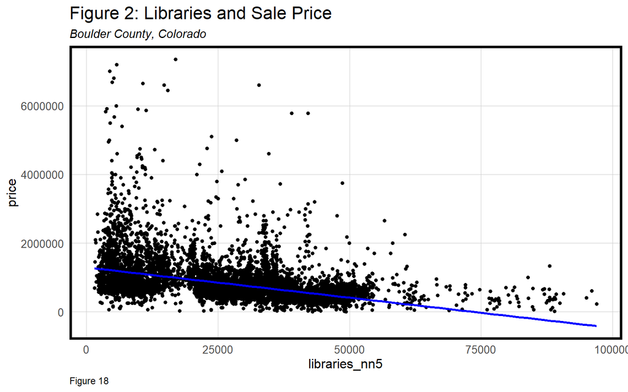

```r
## Libraries
ggplot(data = Training_BoulderPlot, aes(x = libraries_nn5, y = price)) +
  geom_point(size=2, shape=20)  +
  labs(title = "Figure 2: Libraries and Sale Price", subtitle = "Boulder County, Colorado", caption="Figure 18") +
  geom_smooth(method = "lm", se=F, colour = "blue") +
  plotTheme()
## `geom_smooth()` using formula 'y ~ x'
```

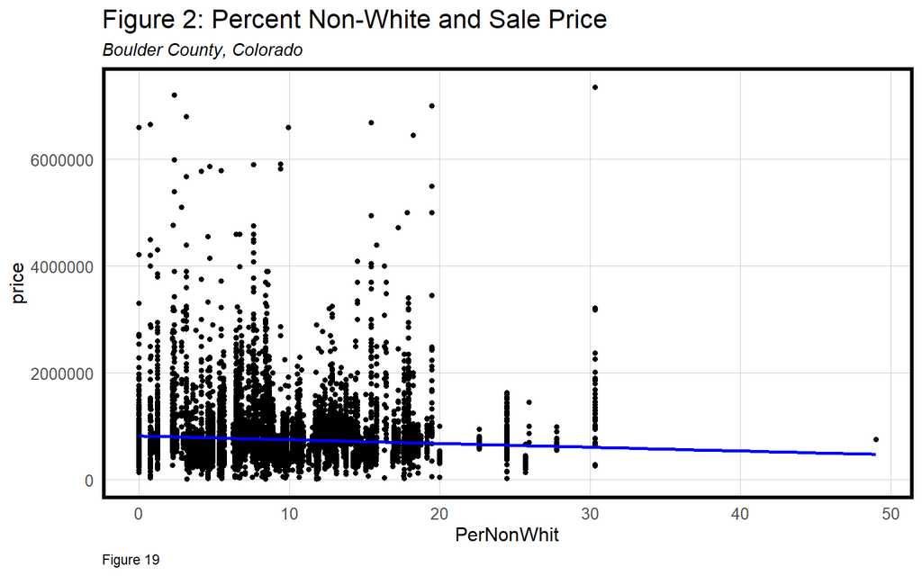

```r
## Percent Non-White
ggplot(data = Training_BoulderPlot, aes(x = PerNonWhit, y = price)) +
  geom_point(size=2, shape=20)  +
  labs(title = "Figure 2: Percent Non-White and Sale Price", subtitle = "Boulder County, Colorado", caption="Figure 19") +
  geom_smooth(method = "lm", se=F, colour = "blue") +
  plotTheme()
## `geom_smooth()` using formula 'y ~ x'
```

# 15 Regression Model

Below is our regression model. The one with categorical variables is our model in final form that was adjusted, significantly, from the first variation. This model includes: basement SF, carstorage SF, total finished SF, # of rooms, total baths, % bachelors or higher, distance from libraries, distance from trailheads, distance from marijuana establishments, distance from private schools, description of geological hazards, basement type, car storage type, quality code description (the state of the housing), block groups, distance from lakes and reservoirs, proximity to scenic corridor, flood zones, and wildfires. We tried to make sure these variables were not colinear. Overall, the many of the variables appeared significant. Our adjusted R-Squared value indicates that our model accounts for 48% of the home price variation.

```r
# First Regression Test
regression <- lm(price ~ ., data = st_drop_geometry(Training_Boulder) %>%
                                 dplyr::select(price, TotalFinishedSF, mainfloorSF, nbrBedRoom, qualityCode, bsmtSF, carStorageSF, nbrRoomsNobath, totalbaths, TotalPop, PerBDorHig, MedHHInc, libraries_nn2, libraries_nn3, libraries_nn4, libraries_nn5, trailheads_nn2, trailheads_nn3, trailheads_nn4, trailheads_nn5, ME_nn1, ME_nn5, private_nn1, private_nn2, private_nn5))
summary(regression)
```

```
##
## Call:
## lm(formula = price ~ ., data = st_drop_geometry(Training_Boulder) %>%
##     dplyr::select(price, TotalFinishedSF, mainfloorSF, nbrBedRoom,
##         qualityCode, bsmtSF, carStorageSF, nbrRoomsNobath, totalbaths,
##         TotalPop, PerBDorHig, MedHHInc, libraries_nn2, libraries_nn3,
##         libraries_nn4, libraries_nn5, trailheads_nn2, trailheads_nn3,
##         trailheads_nn4, trailheads_nn5, ME_nn1, ME_nn5, private_nn1,
##         private_nn2, private_nn5))
##
## Residuals:
##      Min       1Q   Median       3Q      Max
## -1709885  -171918   -22981    99409 30738441
##
## Coefficients:
##                     Estimate   Std. Error t value             Pr(>|t|)
## (Intercept)     196345.29270  48627.68990   4.038         0.0000543301 ***
## TotalFinishedSF    119.17307     10.35982  11.503 < 0.0000000000000002 ***
## mainfloorSF        133.34692     11.26947  11.833 < 0.0000000000000002 ***
## nbrBedRoom      -19529.05542   6910.45879  -2.826              0.00472 **
## qualityCode      21682.89502    891.46813  24.323 < 0.0000000000000002 ***
## bsmtSF             -17.02235      9.11023  -1.868              0.06172 .
## carStorageSF       -19.32101     24.38072  -0.792              0.42810
## nbrRoomsNobath    1947.35529   3713.71236   0.524              0.60003
## totalbaths       42322.77776   7700.09970   5.496         0.0000000396 ***
## TotalPop           -67.89010      4.09364 -16.584 < 0.0000000000000002 ***
## PerBDorHig       -1071.72288    520.86689  -2.058              0.03965 *
## MedHHInc            -0.05499      0.16915  -0.325              0.74510
## libraries_nn2       22.43093      1.99527  11.242 < 0.0000000000000002 ***
## libraries_nn3      -34.72349      7.52147  -4.617         0.0000039444 ***
## libraries_nn4        1.31300     18.88616   0.070              0.94458
## libraries_nn5       -4.78124     11.81557  -0.405              0.68574
## trailheads_nn2     -31.92391     11.20344  -2.849              0.00439 **
## trailheads_nn3      69.55257     30.43155   2.286              0.02230 *
## trailheads_nn4      16.45420     36.95272   0.445              0.65613
## trailheads_nn5     -55.38995     19.87625  -2.787              0.00533 **
## ME_nn1              -0.27206      1.33804  -0.203              0.83889
## ME_nn5               7.50064      1.46969   5.104         0.0000003388 ***
## private_nn1        -27.39653      6.90927  -3.965         0.0000737937 ***
## private_nn2         61.28900     10.65348   5.753         0.0000000090 ***
## private_nn5        -34.67539      6.19878  -5.594         0.0000000227 ***
## ---
## Signif. codes:  0 '***' 0.001 '**' 0.01 '*' 0.05 '.' 0.1 ' ' 1
##
## Residual standard error: 458900 on 11239 degrees of freedom
## Multiple R-squared:  0.4465, Adjusted R-squared:  0.4453
## F-statistic: 377.8 on 24 and 11239 DF,  p-value: < 0.00000000000000022
```

```r
## Regression for Training with CATEGORICAL VARIABLES
regression <- lm(price ~ ., data = st_drop_geometry(Training_Boulder) %>%
                                 dplyr::select(price, bsmtSF, carStorageSF, TotalFinishedSF, nbrRoomsNobath, totalbaths, PerBDorHig, libraries_nn4, trailheads_nn5, ME_nn5,private_nn5, DESCRIPTION, bsmtType, carStorageType,qualityCodeDscr, NAMELSAD, BoulderHousingData.Buffer.LR, SC, FZ, WF))
summary(regression)
```

```
##
## Call:
## lm(formula = price ~ ., data = st_drop_geometry(Training_Boulder) %>%
##     dplyr::select(price, bsmtSF, carStorageSF, TotalFinishedSF,
##         nbrRoomsNobath, totalbaths, PerBDorHig, libraries_nn4,
##         trailheads_nn5, ME_nn5, private_nn5, DESCRIPTION, bsmtType,
##         carStorageType, qualityCodeDscr, NAMELSAD, BoulderHousingData.Buffer.LR,
##         SC, FZ, WF))
##
## Residuals:
##      Min       1Q   Median       3Q      Max
## -2552121  -134852   -25353    93524 30704940
##
## Coefficients:
##                                    Estimate   Std. Error t value
## (Intercept)                     634223.9883   47415.5383  13.376
## bsmtSF                               0.7793      10.3985   0.075
## carStorageSF                        -0.4356      29.4958  -0.015
## TotalFinishedSF                    167.7971       9.9655  16.838
## nbrRoomsNobath                    1250.3196    3234.1281   0.387
## totalbaths                       -4481.5507    7355.0329  -0.609
## PerBDorHig                         101.6115     408.2509   0.249
## libraries_nn4                      -19.9991       0.7089 -28.211
## trailheads_nn5                      -5.3495       1.5436  -3.466
## ME_nn5                               3.4608       0.8521   4.061
## private_nn5                          3.0461       0.9294   3.278
## DESCRIPTIONMinor Constraint     109300.9537   26225.9222   4.168
## DESCRIPTIONModerate Constraint  158821.8189   24252.3469   6.549
## DESCRIPTIONModerate Hazard      194315.8907   42638.3189   4.557
## bsmtTypeBGF                      90418.5142   28898.1756   3.129
## bsmtTypeBGU                     -11087.9792   48525.4199  -0.228
## bsmtTypeBSF                      44884.5845   16419.7457   2.734
## bsmtTypeBSU                     -27770.0097   16054.5824  -1.730
## bsmtTypeBWF                     114399.1891   23333.4548   4.903
## bsmtTypeBWU                     -14143.3437   34793.8569  -0.406
## bsmtTypeLGF                      94007.4392   20266.3963   4.639
## bsmtTypeLGU                     -65158.7185  133997.5780  -0.486
## bsmtTypeLWF                     227951.5813   70318.9978   3.242
## bsmtTypeLWU                     102607.0121  255798.4542   0.401
## carStorageTypeGRA               -42485.3547   21786.7374  -1.950
```

[output cut: 78 more lines]

```
## NAMELSADBlock Group 4                      0.112150
## NAMELSADBlock Group 5                      0.873303
## NAMELSADBlock Group 6                      0.004657 **
## NAMELSADBlock Group 7                      0.167869
## BoulderHousingData.Buffer.LR               0.012527 *
## SC                              0.00000016021498564 ***
## FZ                                         0.302090
## WF                                         0.422670
## ---
## Signif. codes:  0 '***' 0.001 '**' 0.01 '*' 0.05 '.' 0.1 ' ' 1
##
## Residual standard error: 442000 on 11195 degrees of freedom
##   (14 observations deleted due to missingness)
## Multiple R-squared:  0.4884, Adjusted R-squared:  0.4859
## F-statistic: 197.9 on 54 and 11195 DF,  p-value: < 0.00000000000000022
```

```r
#---Polished LM table of training dataset
stargazer(regression, type="text", digits=1, title="Table 3: Linear Model of Training Dataset", out = "Training LM.txt")
```

```
##
## Table 3: Linear Model of Training Dataset
## ==========================================================
##                                    Dependent variable:
##                                ---------------------------
##                                           price
## ----------------------------------------------------------
## bsmtSF                                     0.8
##                                          (10.4)
##
## carStorageSF                              -0.4
##                                          (29.5)
##
## TotalFinishedSF                         167.8***
##                                          (10.0)
##
## nbrRoomsNobath                           1,250.3
##                                         (3,234.1)
##
## totalbaths                              -4,481.6
##                                         (7,355.0)
##
## PerBDorHig                                101.6
##                                          (408.3)
##
## libraries_nn4                           -20.0***
##                                           (0.7)
##
## trailheads_nn5                           -5.3***
##                                           (1.5)
##
## ME_nn5                                   3.5***
##                                           (0.9)
##
## private_nn5                              3.0***
##                                           (0.9)
##
## DESCRIPTIONMinor Constraint           109,301.0***
##                                        (26,225.9)
##
```

[output cut: 125 more lines]

```
##
## WF                                      -48,285.0
##                                        (60,218.7)
##
## Constant                              634,224.0***
##                                        (47,415.5)
##
## ----------------------------------------------------------
## Observations                             11,250
## R2                                         0.5
## Adjusted R2                                0.5
## Residual Std. Error              441,972.7 (df = 11195)
## F Statistic                     197.9*** (df = 54; 11195)
## ==========================================================
## Note:                          *p<0.1; **p<0.05; ***p<0.01
```

# 16 Partition and Predictions

At this point, our data was partitioned in a 75/25 training and test split. First we ran a regression on a training set, which contained 75% of the data. Then using this regression, we carry it over and test its generalizability on the test set.

```r
set.seed(999) #makes sure data is split same way every time

## Partition
inTrain <- createDataPartition(
              y = paste(Training_Boulder$DESCRIPTION),
              p = .75, list = FALSE)

## Creating the training and test set
TrainingBoulder <- BoulderHousingData[inTrain,]
TestBoulder <- BoulderHousingData[-inTrain,]

## Regression on training set post partition.

regression_trainingboulder <- lm(price ~ ., data = st_drop_geometry(TrainingBoulder) %>%
                                 dplyr::select(price, bsmtSF, carStorageSF, TotalFinishedSF, nbrRoomsNobath, totalbaths, PerBDorHig, libraries_nn4, trailheads_nn5, ME_nn5,private_nn5, DESCRIPTION, bsmtType, carStorageType,qualityCodeDscr, NAMELSAD, BoulderHousingData.Buffer.LR, SC, FZ, WF))
summary(regression_trainingboulder)
```

```
##
## Call:
## lm(formula = price ~ ., data = st_drop_geometry(TrainingBoulder) %>%
##     dplyr::select(price, bsmtSF, carStorageSF, TotalFinishedSF,
##         nbrRoomsNobath, totalbaths, PerBDorHig, libraries_nn4,
##         trailheads_nn5, ME_nn5, private_nn5, DESCRIPTION, bsmtType,
##         carStorageType, qualityCodeDscr, NAMELSAD, BoulderHousingData.Buffer.LR,
##         SC, FZ, WF))
##
## Residuals:
##      Min       1Q   Median       3Q      Max
## -2623505  -134293   -22142    96838  4092225
##
## Coefficients:
##                                    Estimate   Std. Error t value
## (Intercept)                     594291.3031   40278.6697  14.754
## bsmtSF                              -1.7972       8.7968  -0.204
## carStorageSF                        -8.3078      25.7035  -0.323
## TotalFinishedSF                    171.5276       8.3962  20.429
## nbrRoomsNobath                    3427.1508    2704.1325   1.267
## totalbaths                       -7329.9540    6163.9311  -1.189
## PerBDorHig                          23.9288     346.4822   0.069
## libraries_nn4                      -19.8555       0.5982 -33.191
## trailheads_nn5                      -4.9605       1.3094  -3.788
## ME_nn5                               4.0976       0.7235   5.663
## private_nn5                          2.5749       0.7857   3.277
## DESCRIPTIONMinor Constraint     116924.6259   22186.7598   5.270
## DESCRIPTIONModerate Constraint  163729.7396   20556.5016   7.965
## DESCRIPTIONModerate Hazard      208366.7869   35819.2264   5.817
## bsmtTypeBGF                     114177.1686   24523.5534   4.656
## bsmtTypeBGU                     -16298.4887   41764.4679  -0.390
## bsmtTypeBSF                      52725.0004   13926.0428   3.786
## bsmtTypeBSU                     -24843.4169   13568.9384  -1.831
## bsmtTypeBWF                     128415.4584   19626.7878   6.543
## bsmtTypeBWU                      -5550.4385   28614.5955  -0.194
## bsmtTypeLGF                     103226.2413   17171.6119   6.011
## bsmtTypeLGU                     -73152.8403  115129.2731  -0.635
## bsmtTypeLWF                     248499.5375   61856.7586   4.017
## bsmtTypeLWU                     156921.1731  229407.5524   0.684
## carStorageTypeGRA               -47941.5780   18508.5265  -2.590
```

[output cut: 78 more lines]

```
## NAMELSADBlock Group 4                      0.004291 **
## NAMELSADBlock Group 5                      0.473996
## NAMELSADBlock Group 6                      0.000294 ***
## NAMELSADBlock Group 7                      0.197996
## BoulderHousingData.Buffer.LR               0.009727 **
## SC                              0.00000000370709615 ***
## FZ                                         0.120873
## WF                                         0.270888
## ---
## Signif. codes:  0 '***' 0.001 '**' 0.01 '*' 0.05 '.' 0.1 ' ' 1
##
## Residual standard error: 323600 on 8384 degrees of freedom
##   (11 observations deleted due to missingness)
## Multiple R-squared:  0.6479, Adjusted R-squared:  0.6456
## F-statistic: 285.7 on 54 and 8384 DF,  p-value: < 0.00000000000000022
```

```r
## Using the regression from training, we test it on the TestBoulder dataset.
TestBoulder <-
  TestBoulder %>%
  mutate(Price.Predict = predict(regression_trainingboulder, TestBoulder),
         Price.Error = Price.Predict - price,
         Price.AbsError = abs(Price.Predict - price),
         Price.APE = (abs(Price.Predict - price)) / Price.Predict)

## CHALLENGE
#Predictions <- filter(TestBoulder, toPredict == 1)

#PredictionsExport <- subset(Predictions, select = c("MUSA_ID", "Price.Predict")) %>% st_drop_geometry()

#write.csv(PredictionsExport, "TheDevelopers.csv")
```

# 17 Accuracy, K-Fold, and Cross Validation

To determine our model’s generalizability even further, we use K-Folds. With our folds set to 100, we run a general regression, then test on these folds. In our outcome, we see that the distribution of errors clusters at a handful of prices with a few outliers. For example, there is a cluster at $160,000-170,000 and $180,000-$200,000. This is also seen in our table of the cross validation as the mean is $186,502 with a standard deviation of $26,582 which explains the aforementioned $160,000-170,000 cluster or the higher price error cluster at around $210,000-$230,000.

```r
## Accuracy - Mean Absolute Error
mean(TestBoulder$Price.AbsError, na.rm = T) #MAE
```

```
## [1] 198961.8
```

```r
mean(TestBoulder$Price.APE, na.rm = T) #MAPE
```

```
## [1] 0.3382933
```

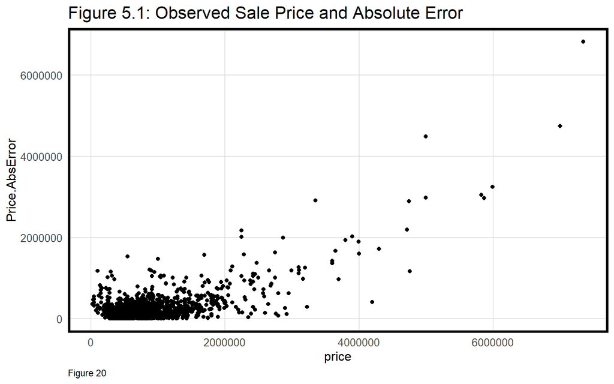

```r
TestBoulderFilter <-
  TestBoulder %>%
  filter(price < 10000000)

ggplot(data = TestBoulderFilter) +
  geom_point(aes(x = price, y = Price.AbsError)) +
  labs(title = "Figure 5.1: Observed Sale Price and Absolute Error", caption="Figure 20") +
  plotTheme()
```

```r
## K-Fold: Generalizability Cross-Validation
fitControl <- trainControl(method = "cv", number = 100)
set.seed(825)

reg.cv <-
  train(price ~ ., data = st_drop_geometry(TrainingBoulder) %>%
                                dplyr::select(price, bsmtSF, carStorageSF, TotalFinishedSF,
                                              nbrRoomsNobath, totalbaths, PerBDorHig, libraries_nn4,
                                              trailheads_nn5, ME_nn5,private_nn5, DESCRIPTION, bsmtType,
                                              carStorageType, qualityCodeDscr, NAMELSAD,
                                              BoulderHousingData.Buffer.LR, SC, FZ, WF),
method = "lm", trControl = fitControl, na.action = na.pass)

reg.cv
## Linear Regression
##
## 8450 samples
##   19 predictor
##
## No pre-processing
## Resampling: Cross-Validated (100 fold)
## Summary of sample sizes: 8365, 8364, 8366, 8366, 8364, 8366, ...
## Resampling results:
##
##   RMSE      Rsquared  MAE
##   315859.4  0.652139  186502.5
##
## Tuning parameter 'intercept' was held constant at a value of TRUE

reg.cv$resample[1:5,]
```

```
##       RMSE  Rsquared      MAE Resample
## 1 473573.2 0.8360428 215043.0  Fold001
## 2 273969.7 0.6867823 188634.5  Fold002
## 3 601262.2 0.5648825 262725.7  Fold003
## 4 281072.0 0.4537136 176475.9  Fold004
## 5 221181.9 0.6074200 149147.4  Fold005
```

```r
mean(reg.cv$resample[,3])
```

```
## [1] 186502.5
```

```r
reg.cv$resample[7,]
```

```
##       RMSE  Rsquared      MAE Resample
## 7 332309.4 0.5880404 215540.4  Fold007
```

```r
stargazer(as.data.frame(reg.cv$resample), type="text", digits=1, title="Cross Validation Results", caption="Figure 21", out = "CV.txt") #all cv
```

```
##
## Cross Validation Results
## ========================================================================
## Statistic  N    Mean    St. Dev.    Min    Pctl(25)  Pctl(75)     Max
## ------------------------------------------------------------------------
## RMSE      100 315,859.4 90,018.5 178,474.4 245,708.6 363,252.5 601,262.2
## Rsquared  100    0.7      0.1       0.3       0.6       0.7       0.9
## MAE       100 186,502.5 26,582.9 136,335.8 167,758.1 203,090.7 273,585.2
## ------------------------------------------------------------------------
##
## Cross Validation Results
## =========
## Figure 21
## ---------
```

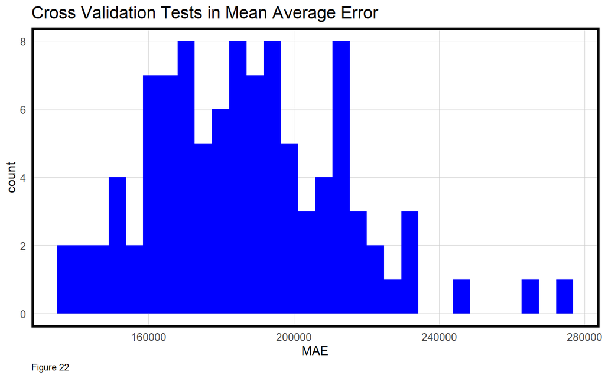

```r
ggplot(reg.cv$resample, aes(x=MAE)) +
  geom_histogram(fill = "blue") +
  labs(title = "Cross Validation Tests in Mean Average Error", caption="Figure 22") +
  plotTheme()
## `stat_bin()` using `bins = 30`. Pick better value with `binwidth`.
```